# JuneInterruption

```r
# Load packages
library(tidyverse)
```

```r
library(ggplot2)
library(readxl)
library(lubridate)
library(broom)
library(viridis)
library(tsModel)
library(scales)
library(grid)
library(tseries)
library(tsibble)
library(fable)
library(feasts)
library(forecast)

# Global options
knitr::opts_chunk$set(echo = TRUE, warning = FALSE, message = FALSE)
source("functions.R")
```

# 1 All-Cause

## ARIMA model

The Fable algorithm will dictate the model parameters. Next, we plot the residuals, the ACF plot, and a histogram to ensure they approximate a white noise series.

```r
# Use automated algorithm to identify p/q parameters
# Specify first difference = 1 and seasonal difference = 1
f_arima <- monthly_f.ts %>%  #female
  model(arima = ARIMA(Deaths ~ step + ramp,
                      stepwise = FALSE,
                      trace = TRUE))
m_arima <- monthly_m.ts %>%  #male
  model(arima = ARIMA(Deaths ~ step + ramp,
                      stepwise = FALSE,
                      trace = TRUE))
```

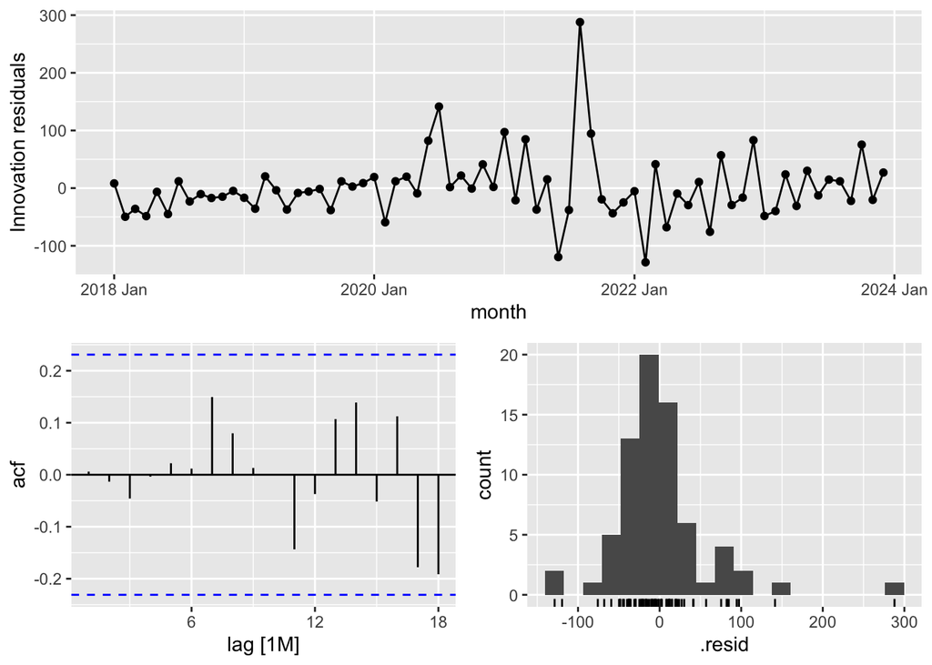

```r
#Plotting model residuals
f_arima  %>%
  gg_tsresiduals()
```

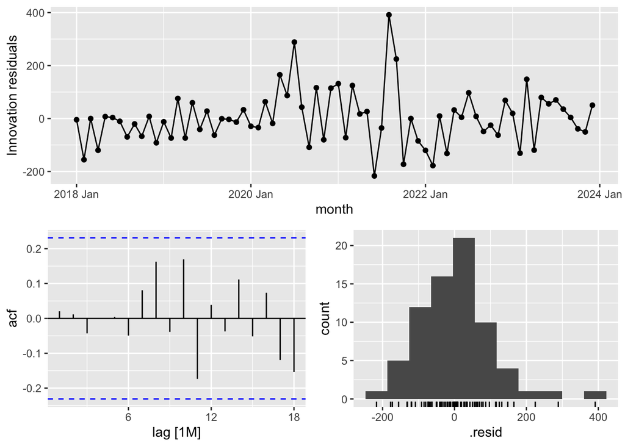

```r
m_arima  %>%
  gg_tsresiduals()
```

Here we use the Ljung-Box test, which models if the residuals are still autocorrelated. Null: residuals are independent (white noise) Alternative: residuals show remaining autocorrelation

```r
#Ljung-Box test
augment(f_arima ) %>%
  features(.resid, ljung_box)
```

```
## # A tibble: 1 × 3
##   .model lb_stat lb_pvalue
##   <chr>    <dbl>     <dbl>
## 1 arima  0.00276     0.958
```

```r
augment(m_arima ) %>%
  features(.resid, ljung_box)
```

```
## # A tibble: 1 × 3
##   .model lb_stat lb_pvalue
##   <chr>    <dbl>     <dbl>
## 1 arima   0.0314     0.859
```

With the model assumptions satisfied, we can take a look at the model estimates:

```r
report(m_arima)
```

```
## Series: Deaths
## Model: LM w/ ARIMA(4,0,0) errors
##
## Coefficients:
##          ar1      ar2     ar3     ar4      step      ramp  intercept
##       0.8266  -0.4011  0.1343  0.2315  377.0418  -10.1464   905.9817
## s.e.  0.1171   0.1521  0.1510  0.1159   91.8799    5.3946    65.5346
##
## sigma^2 estimated as 11478:  log likelihood=-435.67
## AIC=887.33   AICc=889.62   BIC=905.54
```

```r
report(f_arima)
```

```
## Series: Deaths
## Model: LM w/ ARIMA(4,0,0) errors
##
## Coefficients:
##          ar1      ar2      ar3     ar4     step     ramp  intercept
##       0.6380  -0.1338  -0.1073  0.3361  140.306  -3.4020   424.9892
## s.e.  0.1136   0.1326   0.1333  0.1104   49.707   2.6703    29.4805
##
## sigma^2 estimated as 3578:  log likelihood=-393.54
## AIC=803.09   AICc=805.38   BIC=821.3
```

```r
#Modeling counterfactual male
m_counterfactual <- monthly_m.ts %>%
  filter(month < make_yearmonth(2021, 6)) %>%
  model(
    arima_null = ARIMA(
      Deaths,
      stepwise = FALSE
    )
  )
report(m_counterfactual)
```

```
## Series: Deaths
## Model: ARIMA(0,1,0)(1,0,0)[12]
##
## Coefficients:
##         sar1
##       0.3645
## s.e.  0.1951
##
## sigma^2 estimated as 6432:  log likelihood=-232.49
## AIC=468.97   AICc=469.3   BIC=472.35
```

```r
#Modeling counterfactual female
f_counterfactual <- monthly_f.ts %>%
  filter(month < make_yearmonth(2021, 6)) %>%
  model(
    arima_null = ARIMA(
      Deaths,
      stepwise = FALSE
    )
  )
report(f_counterfactual)
```

```
## Series: Deaths
## Model: ARIMA(1,1,3)
##
## Coefficients:
##           ar1     ma1      ma2      ma3
##       -0.9660  0.8037  -0.3491  -0.4509
## s.e.   0.0523  0.1883   0.1693   0.1621
##
## sigma^2 estimated as 1378:  log likelihood=-200.23
## AIC=410.45   AICc=412.22   BIC=418.9
```

[figure not shown]

```r
#forecast into post-intervention period  male
fc_m_counterfactual <- m_counterfactual %>%
  forecast(h = 28)

 autoplot(fc_m_counterfactual, monthly_m.ts, level = 95) +
  geom_vline(
    xintercept = as.numeric(as_date(make_yearmonth(2021, 6))),
    linetype = "dashed",
    color = "grey40"
  ) +
  labs(
    title = "Observed vs Counterfactual Male Assault Deaths",
    y = "Monthly Deaths",
    x = "Month"
  ) +
  scale_y_continuous(expand = c(0, 0)) +
  theme_minimal() +
  theme(
    panel.grid.major.x = element_blank(),
    panel.grid.minor.x = element_blank()
  )
```

[figure not shown]

```r
 #forecast into post-intervention period male
fc_f_counterfactual <- f_counterfactual %>%
  forecast(h = 28+6)

 autoplot(fc_f_counterfactual, monthly_f.ts, level = 95) +
  geom_vline(
    xintercept = as.numeric(as_date(make_yearmonth(2021, 6))),
    linetype = "dashed",
    color = "grey40"
  ) +
  labs(
    title = "Observed vs Counterfactual Female Assault Deaths",
    y = "Monthly Deaths",
    x = "Month"
  ) +
  scale_y_continuous(expand = c(0, 0)) +
  theme_minimal() +
  theme(
    panel.grid.major.x = element_blank(),
    panel.grid.minor.x = element_blank()
  )
```

## Sensitivity

**Step 1: Fit ARIMA using pre-intervention data only**

Subsetting pre-intervention data:

```r
pre_data_f <- monthly_f.ts %>%
  filter(month_year < as.Date("2021-06-01"))

pre_data_m <- monthly_m.ts %>%
  filter(month_year < as.Date("2021-06-01"))
```

Selecting ARIMA from pre-period data only:

```r
m_pre <- pre_data_m %>%
  model(arima = ARIMA(Deaths, stepwise = FALSE))

f_pre <- pre_data_f %>%
  model(arima = ARIMA(Deaths, stepwise = FALSE))
```

```r
report(m_pre)
```

```
## Series: Deaths
## Model: ARIMA(0,1,0)(1,0,0)[12]
##
## Coefficients:
##         sar1
##       0.3645
## s.e.  0.1951
##
## sigma^2 estimated as 6432:  log likelihood=-232.49
## AIC=468.97   AICc=469.3   BIC=472.35
```

```r
report(f_pre)
```

```
## Series: Deaths
## Model: ARIMA(1,1,3)
##
## Coefficients:
##           ar1     ma1      ma2      ma3
##       -0.9660  0.8037  -0.3491  -0.4509
## s.e.   0.0523  0.1883   0.1693   0.1621
##
## sigma^2 estimated as 1378:  log likelihood=-200.23
## AIC=410.45   AICc=412.22   BIC=418.9
```

**Step 2: Refit to full data**

```r
m_sensitivity <- monthly_m.ts %>%
  model(
    arima = ARIMA(
      Deaths ~ step + ramp + pdq(0,1,0) + PDQ(1,0,0),
      stepwise = FALSE
    )
  )

f_sensitivity <- monthly_f.ts %>%
  model(
    arima = ARIMA(
      Deaths ~ step + ramp + pdq(1,1,3),
      stepwise = FALSE
    )
  )
```

**Step 3: Comparing estimates**

```r
#male
report(m_arima)
```

```
## Series: Deaths
## Model: LM w/ ARIMA(4,0,0) errors
##
## Coefficients:
##          ar1      ar2     ar3     ar4      step      ramp  intercept
##       0.8266  -0.4011  0.1343  0.2315  377.0418  -10.1464   905.9817
## s.e.  0.1171   0.1521  0.1510  0.1159   91.8799    5.3946    65.5346
##
## sigma^2 estimated as 11478:  log likelihood=-435.67
## AIC=887.33   AICc=889.62   BIC=905.54
```

```r
report(m_sensitivity)
```

```
## Series: Deaths
## Model: LM w/ ARIMA(0,1,0)(1,0,0)[12] errors
##
## Coefficients:
##          sar1      step     ramp
##       -0.0427   93.3978  -6.2937
## s.e.   0.1163  124.6842  21.7552
##
## sigma^2 estimated as 15598:  log likelihood=-441.97
## AIC=891.94   AICc=892.55   BIC=901
```

```r
#female
report(f_arima)
```

```
## Series: Deaths
## Model: LM w/ ARIMA(4,0,0) errors
##
## Coefficients:
##          ar1      ar2      ar3     ar4     step     ramp  intercept
##       0.6380  -0.1338  -0.1073  0.3361  140.306  -3.4020   424.9892
## s.e.  0.1136   0.1326   0.1333  0.1104   49.707   2.6703    29.4805
##
## sigma^2 estimated as 3578:  log likelihood=-393.54
## AIC=803.09   AICc=805.38   BIC=821.3
```

```r
report(f_sensitivity)
```

```
## Series: Deaths
## Model: LM w/ ARIMA(1,1,3) errors
##
## Coefficients:
##           ar1     ma1      ma2      ma3     step     ramp
##       -0.3325  0.0737  -0.3372  -0.3927  89.3100  -4.4608
## s.e.   0.2652  0.2321   0.1408   0.1272  51.9976   3.4429
##
## sigma^2 estimated as 3816:  log likelihood=-390.79
## AIC=795.58   AICc=797.36   BIC=811.42
```

# 2 Assault COD

```r
# Create variable representing step and ramp changes
intervention_month <- monthly_f.ts %>%
  filter(month_year == "2021-06-01") %>%
  pull(time)

monthly_f.ts<- monthly_f.ts %>%
  mutate(
    t = row_number(),
    step = if_else(t >= intervention_month, 1, 0),
    ramp = if_else(t >= intervention_month, t - intervention_month + 1, 0)
  )

intervention_month <- monthly_m.ts %>%
  filter(month_year == "2021-06-01") %>%
  pull(time)

monthly_m.ts <- monthly_m.ts %>%
  mutate(
    t = row_number(),
    step = if_else(t >= intervention_month, 1, 0),
    ramp = if_else(t >= intervention_month, t - intervention_month + 1, 0)
  )

#View the step and ramp variables
monthly_f.ts %>%  #female
  pivot_longer(
    cols = c(step, ramp),
    names_to = "variables",
    values_to = "value"
  ) %>%
  ggplot(aes(x = month_year, y = value, color = variables)) +
  geom_line(linewidth = 1) +
  geom_vline(
    xintercept = as.Date("2021-06-01"),
    linetype = "dashed",
    color = "black"
  ) +
  labs(
    title = "Step and Ramp Variables - Female",
    x = "Month",
    y = "Value",
    color = ""
  ) +
  scale_x_date(date_breaks = "1 year", date_labels = "%Y") +
  theme_minimal()
```

[output not shown]

```r
monthly_m.ts %>% #male
  pivot_longer(
    cols = c(step, ramp),
    names_to = "variables",
    values_to = "value"
  ) %>%
  ggplot(aes(x = month_year, y = value, color = variables)) +
  geom_line(linewidth = 1) +
  geom_vline(
    xintercept = as.Date("2021-06-01"),
    linetype = "dashed",
    color = "black"
  ) +
  labs(
    title = "Step and Ramp Variables - Male",
    x = "Month",
    y = "Value",
    color = ""
  ) +
  scale_x_date(date_breaks = "1 year", date_labels = "%Y") +
  theme_minimal()
```

[output not shown]

## ARIMA model

The Fable algorithm will dictate the model parameters. Next, we plot the residuals, the ACF plot, and a histogram to ensure they approximate a white noise series.

```r
# Use automated algorithm to identify p/q parameters
# Specify first difference = 1 and seasonal difference = 1
f_arima <- monthly_f.ts %>%  #female
  model(arima = ARIMA(Deaths ~ step + ramp,
                      stepwise = FALSE,
                      trace = TRUE))
m_arima <- monthly_m.ts %>%  #male
  model(arima = ARIMA(Deaths ~ step + ramp,
                      stepwise = FALSE,
                      trace = TRUE))
```

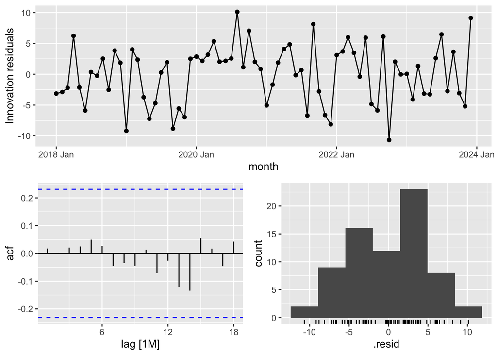

```r
#Plotting model residuals
f_arima  %>%
  gg_tsresiduals()
```

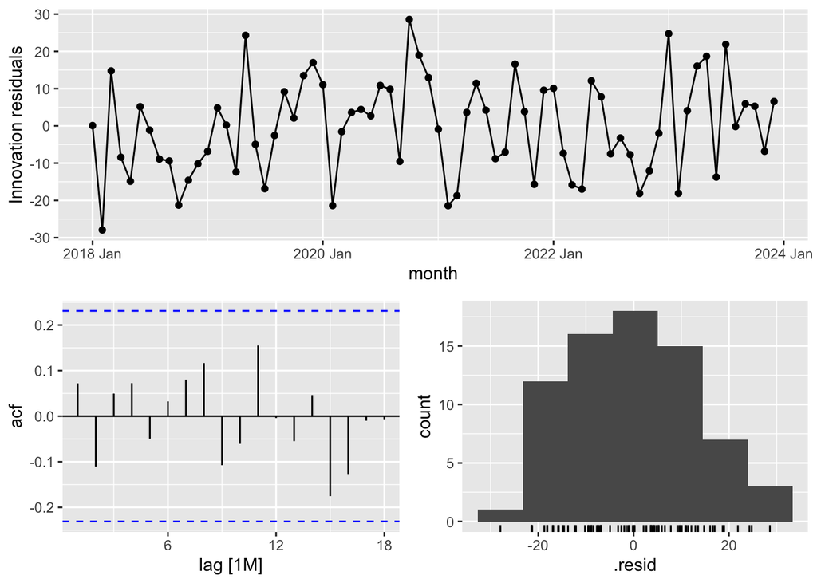

```r
m_arima  %>%
  gg_tsresiduals()
```

Here we use the Ljung-Box test, which models if the residuals are still autocorrelated. Null: residuals are independent (white noise) Alternative: residuals show remaining autocorrelation

```r
#Ljung-Box test
augment(f_arima ) %>%
  features(.resid, ljung_box)
```

```
## # A tibble: 1 × 3
##   .model lb_stat lb_pvalue
##   <chr>    <dbl>     <dbl>
## 1 arima   0.0237     0.878
```

```r
augment(m_arima ) %>%
  features(.resid, ljung_box)
```

```
## # A tibble: 1 × 3
##   .model lb_stat lb_pvalue
##   <chr>    <dbl>     <dbl>
## 1 arima    0.389     0.533
```

With the model assumptions satisfied, we can take a look at the model estimates:

```r
report(m_arima)
```

```
## Series: Deaths
## Model: LM w/ ARIMA(0,1,1)(1,0,0)[12] errors
##
## Coefficients:
##           ma1    sar1    step     ramp  intercept
##       -0.8051  0.2867  1.9327  -2.5354     1.4407
## s.e.   0.0898  0.1307  7.8154   0.7998     0.5525
##
## sigma^2 estimated as 179.3:  log likelihood=-283.39
## AIC=578.77   AICc=580.09   BIC=592.35
```

```r
report(f_arima)
```

```
## Series: Deaths
## Model: LM w/ ARIMA(0,0,5) errors
##
## Coefficients:
##           ma1      ma2     ma3     ma4     ma5    step     ramp  intercept
##       -0.0005  -0.1056  0.1257  0.2347  0.3621  5.1949  -0.0727    19.4511
## s.e.   0.1134   0.1174  0.1035  0.1113  0.1182  2.3892   0.1241     1.1175
##
## sigma^2 estimated as 24.48:  log likelihood=-213.66
## AIC=445.31   AICc=448.22   BIC=465.8
```

```r
#Modeling counterfactual male
m_counterfactual <- monthly_m.ts %>%
  filter(month < make_yearmonth(2021, 6)) %>%
  model(
    arima_null = ARIMA(
      Deaths,
      stepwise = FALSE
    )
  )
report(m_counterfactual)
```

```
## Series: Deaths
## Model: ARIMA(0,1,1) w/ drift
##
## Coefficients:
##           ma1  constant
##       -0.7579    1.3786
## s.e.   0.1281    0.5786
##
## sigma^2 estimated as 196.6:  log likelihood=-161.78
## AIC=329.57   AICc=330.23   BIC=334.63
```

```r
#Modeling counterfactual female
f_counterfactual <- monthly_f.ts %>%
  filter(month < make_yearmonth(2021, 6)) %>%
  model(
    arima_null = ARIMA(
      Deaths,
      stepwise = FALSE
    )
  )
report(f_counterfactual)
```

```
## Series: Deaths
## Model: ARIMA(4,1,0)
##
## Coefficients:
##           ar1      ar2      ar3      ar4
##       -0.6631  -0.7392  -0.5346  -0.2745
## s.e.   0.1521   0.1621   0.1627   0.1523
##
## sigma^2 estimated as 23.42:  log likelihood=-118.36
## AIC=246.72   AICc=248.48   BIC=255.16
```

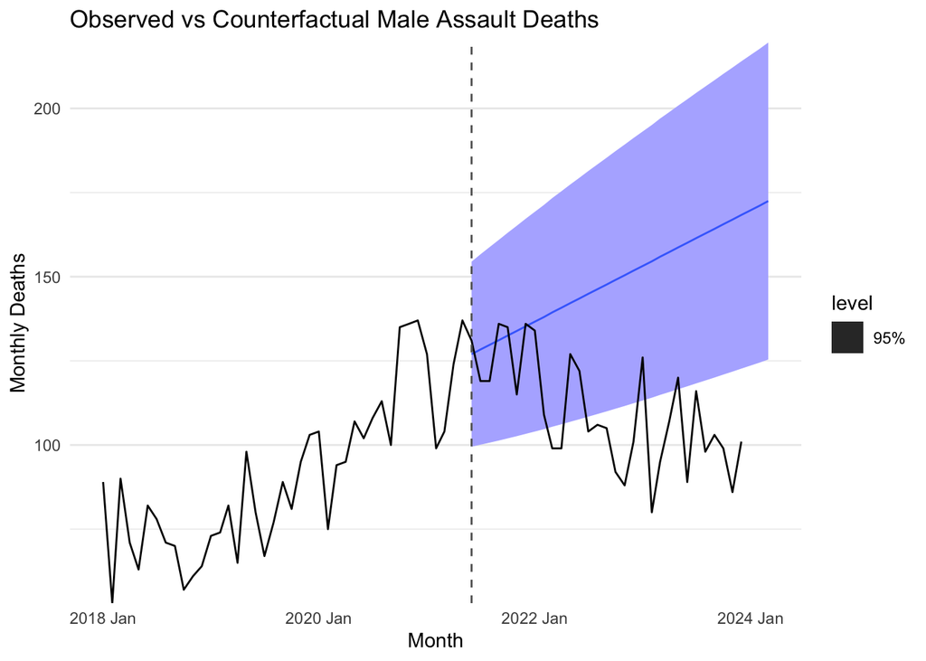

```r
#forecast into post-intervention period  male
fc_m_counterfactual <- m_counterfactual %>%
  forecast(h = 28+6)

 autoplot(fc_m_counterfactual, monthly_m.ts, level = 95) +
  geom_vline(
    xintercept = as.numeric(as_date(make_yearmonth(2021, 6))),
    linetype = "dashed",
    color = "grey40"
  ) +
  labs(
    title = "Observed vs Counterfactual Male Assault Deaths",
    y = "Monthly Deaths",
    x = "Month"
  ) +
  scale_y_continuous(expand = c(0, 0)) +
  theme_minimal() +
  theme(
    panel.grid.major.x = element_blank(),
    panel.grid.minor.x = element_blank()
  )
```

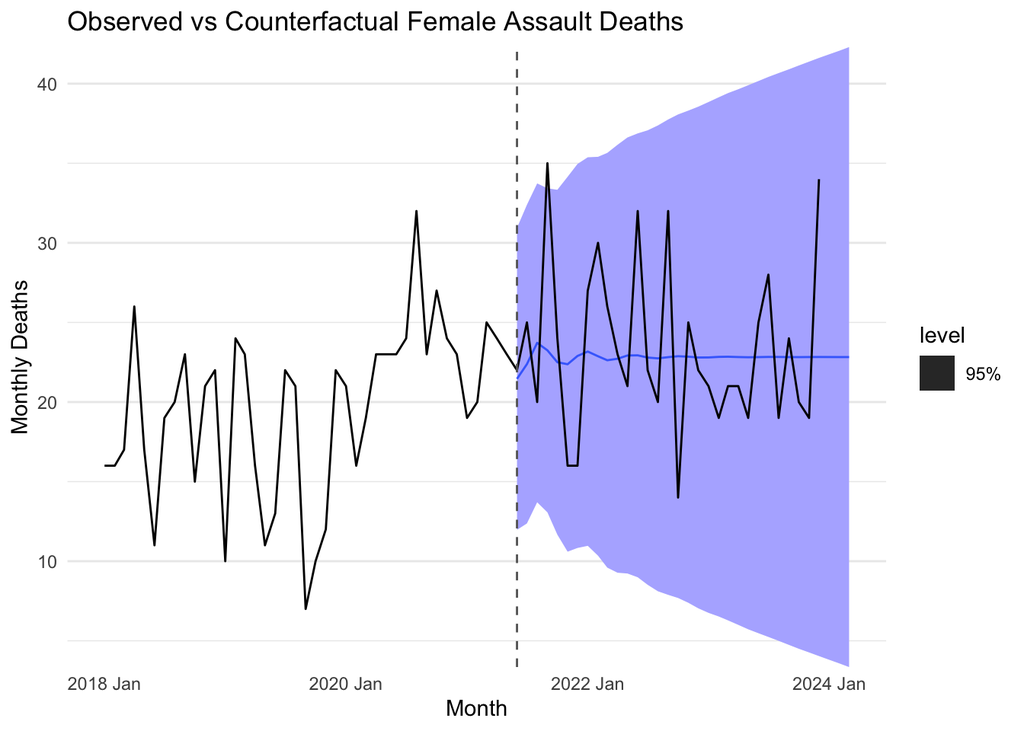

```r
 #forecast into post-intervention period male
fc_f_counterfactual <- f_counterfactual %>%
  forecast(h = 28+6)

 autoplot(fc_f_counterfactual, monthly_f.ts, level = 95) +
  geom_vline(
    xintercept = as.numeric(as_date(make_yearmonth(2021, 6))),
    linetype = "dashed",
    color = "grey40"
  ) +
  labs(
    title = "Observed vs Counterfactual Female Assault Deaths",
    y = "Monthly Deaths",
    x = "Month"
  ) +
  scale_y_continuous(expand = c(0, 0)) +
  theme_minimal() +
  theme(
    panel.grid.major.x = element_blank(),
    panel.grid.minor.x = element_blank()
  )
```

## 2.1 Sensitivity

**Step 1: Fit ARIMA using pre-intervention data only**

Subsetting pre-intervention data:

```r
pre_data_f <- monthly_f.ts %>%
  filter(month_year < as.Date("2021-06-01"))

pre_data_m <- monthly_m.ts %>%
  filter(month_year < as.Date("2021-06-01"))
```

Selecting ARIMA from pre-period data only:

```r
m_pre <- pre_data_m %>%
  model(arima = ARIMA(Deaths, stepwise = FALSE))

f_pre <- pre_data_f %>%
  model(arima = ARIMA(Deaths, stepwise = FALSE))
```

```r
report(m_pre)
```

```
## Series: Deaths
## Model: ARIMA(0,1,1) w/ drift
##
## Coefficients:
##           ma1  constant
##       -0.7579    1.3786
## s.e.   0.1281    0.5786
##
## sigma^2 estimated as 196.6:  log likelihood=-161.78
## AIC=329.57   AICc=330.23   BIC=334.63
```

```r
report(f_pre)
```

```
## Series: Deaths
## Model: ARIMA(4,1,0)
##
## Coefficients:
##           ar1      ar2      ar3      ar4
##       -0.6631  -0.7392  -0.5346  -0.2745
## s.e.   0.1521   0.1621   0.1627   0.1523
##
## sigma^2 estimated as 23.42:  log likelihood=-118.36
## AIC=246.72   AICc=248.48   BIC=255.16
```

**Step 2: Refit to full data**

```r
m_sensitivity <- monthly_m.ts %>%
  model(
    arima = ARIMA(
      Deaths ~ step + ramp + pdq(0,1,1),
      stepwise = FALSE
    )
  )

f_sensitivity <- monthly_f.ts %>%
  model(
    arima = ARIMA(
      Deaths ~ step + ramp + pdq(4,1,0),
      stepwise = FALSE
    )
  )
```

**Step 3: Comparing estimates**

```r
#male
report(m_arima)
```

```
## Series: Deaths
## Model: LM w/ ARIMA(0,1,1)(1,0,0)[12] errors
##
## Coefficients:
##           ma1    sar1    step     ramp  intercept
##       -0.8051  0.2867  1.9327  -2.5354     1.4407
## s.e.   0.0898  0.1307  7.8154   0.7998     0.5525
##
## sigma^2 estimated as 179.3:  log likelihood=-283.39
## AIC=578.77   AICc=580.09   BIC=592.35
```

```r
report(m_sensitivity)
```

```
## Series: Deaths
## Model: LM w/ ARIMA(0,1,1)(1,0,0)[12] errors
##
## Coefficients:
##           ma1    sar1    step     ramp  intercept
##       -0.8051  0.2867  1.9327  -2.5354     1.4407
## s.e.   0.0898  0.1307  7.8154   0.7998     0.5525
##
## sigma^2 estimated as 179.3:  log likelihood=-283.39
## AIC=578.77   AICc=580.09   BIC=592.35
```

```r
#female
report(f_arima)
```

```
## Series: Deaths
## Model: LM w/ ARIMA(0,0,5) errors
##
## Coefficients:
##           ma1      ma2     ma3     ma4     ma5    step     ramp  intercept
##       -0.0005  -0.1056  0.1257  0.2347  0.3621  5.1949  -0.0727    19.4511
## s.e.   0.1134   0.1174  0.1035  0.1113  0.1182  2.3892   0.1241     1.1175
##
## sigma^2 estimated as 24.48:  log likelihood=-213.66
## AIC=445.31   AICc=448.22   BIC=465.8
```

```r
report(f_sensitivity)
```

```
## Series: Deaths
## Model: LM w/ ARIMA(4,1,0) errors
##
## Coefficients:
##           ar1      ar2      ar3      ar4    step     ramp
##       -0.8400  -0.8485  -0.6215  -0.4028  2.2709  -0.0205
## s.e.   0.1143   0.1319   0.1321   0.1130  3.0165   0.2586
##
## sigma^2 estimated as 26.97:  log likelihood=-215.38
## AIC=444.76   AICc=446.54   BIC=460.6
```

# 3 All ages

```r
# Create variable representing step and ramp changes
intervention_month <- monthly_f.ts %>%
  filter(month_year == "2021-06-01") %>%
  pull(time)

monthly_f.ts<- monthly_f.ts %>%
  mutate(
    t = row_number(),
    step = if_else(t >= intervention_month, 1, 0),
    ramp = if_else(t >= intervention_month, t - intervention_month + 1, 0)
  )

intervention_month <- monthly_m.ts %>%
  filter(month_year == "2021-06-01") %>%
  pull(time)

monthly_m.ts <- monthly_m.ts %>%
  mutate(
    t = row_number(),
    step = if_else(t >= intervention_month, 1, 0),
    ramp = if_else(t >= intervention_month, t - intervention_month + 1, 0)
  )

#View the step and ramp variables
monthly_f.ts %>%  #female
  pivot_longer(
    cols = c(step, ramp),
    names_to = "variables",
    values_to = "value"
  ) %>%
  ggplot(aes(x = month_year, y = value, color = variables)) +
  geom_line(linewidth = 1) +
  geom_vline(
    xintercept = as.Date("2021-06-01"),
    linetype = "dashed",
    color = "black"
  ) +
  labs(
    title = "Step and Ramp Variables - Female",
    x = "Month",
    y = "Value",
    color = ""
  ) +
  scale_x_date(date_breaks = "1 year", date_labels = "%Y") +
  theme_minimal()
```

[output not shown]

```r
monthly_m.ts %>% #male
  pivot_longer(
    cols = c(step, ramp),
    names_to = "variables",
    values_to = "value"
  ) %>%
  ggplot(aes(x = month_year, y = value, color = variables)) +
  geom_line(linewidth = 1) +
  geom_vline(
    xintercept = as.Date("2021-06-01"),
    linetype = "dashed",
    color = "black"
  ) +
  labs(
    title = "Step and Ramp Variables - Male",
    x = "Month",
    y = "Value",
    color = ""
  ) +
  scale_x_date(date_breaks = "1 year", date_labels = "%Y") +
  theme_minimal()
```

[output not shown]

## 3.1 ARIMA model

The Fable algorithm will dictate the model parameters. Next, we plot the residuals, the ACF plot, and a histogram to ensure they approximate a white noise series.

```r
# Use automated algorithm to identify p/q parameters
# Specify first difference = 1 and seasonal difference = 1
f_arima <- monthly_f.ts %>%  #female
  model(arima = ARIMA(Deaths ~ step + ramp,
                      stepwise = FALSE,
                      trace = TRUE))
m_arima <- monthly_m.ts %>%  #male
  model(arima = ARIMA(Deaths ~ step + ramp,
                      stepwise = FALSE,
                      trace = TRUE))
```

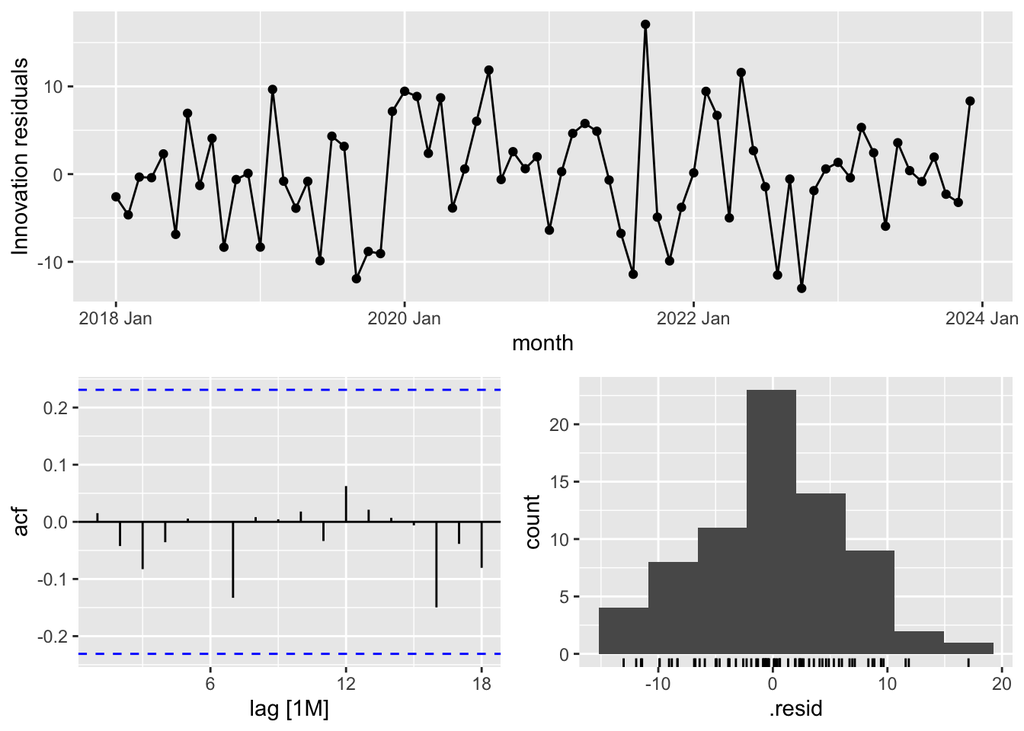

```r
#Plotting model residuals
f_arima  %>%
  gg_tsresiduals()
```

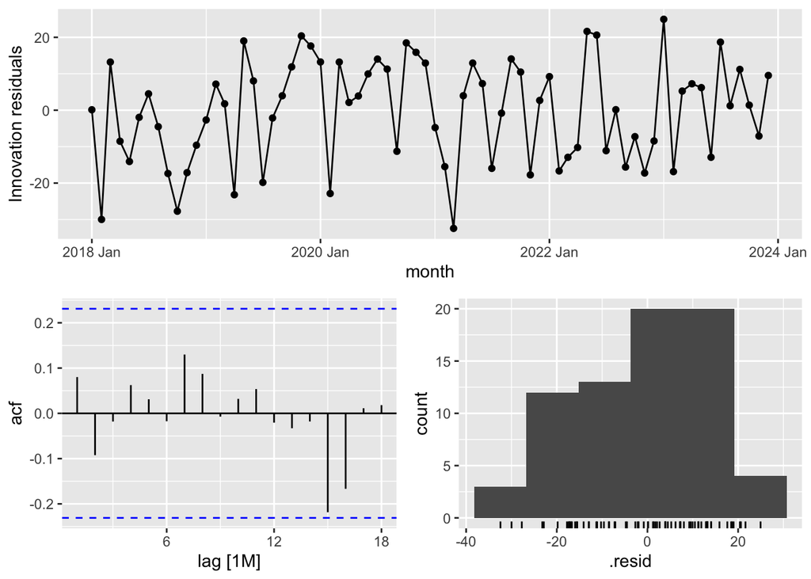

```r
m_arima  %>%
  gg_tsresiduals()
```

Here we use the Ljung-Box test, which models if the residuals are still autocorrelated. Null: residuals are independent (white noise) Alternative: residuals show remaining autocorrelation

```r
#Ljung-Box test
augment(f_arima ) %>%
  features(.resid, ljung_box)
```

```
## # A tibble: 1 × 3
##   .model lb_stat lb_pvalue
##   <chr>    <dbl>     <dbl>
## 1 arima   0.0174     0.895
```

```r
augment(m_arima ) %>%
  features(.resid, ljung_box)
```

```
## # A tibble: 1 × 3
##   .model lb_stat lb_pvalue
##   <chr>    <dbl>     <dbl>
## 1 arima    0.481     0.488
```

With the model assumptions satisfied, we can take a look at the model estimates:

```r
report(m_arima)
```

```
## Series: Deaths
## Model: LM w/ ARIMA(0,1,1)(0,0,1)[12] errors
##
## Coefficients:
##           ma1   sma1    step     ramp  intercept
##       -0.8094  0.326  5.0309  -2.6469     1.5687
## s.e.   0.0866  0.144  8.4125   0.9048     0.5956
##
## sigma^2 estimated as 210.9:  log likelihood=-289.3
## AIC=590.6   AICc=591.91   BIC=604.18
```

```r
report(f_arima)
```

```
## Series: Deaths
## Model: LM w/ ARIMA(0,0,5) errors
##
## Coefficients:
##          ma1     ma2     ma3     ma4     ma5    step     ramp  intercept
##       0.1859  0.0016  0.1026  0.4156  0.3399  9.4181  -0.0682    31.9866
## s.e.  0.1089  0.1029  0.1164  0.1490  0.1287  4.0718   0.2071     1.9153
##
## sigma^2 estimated as 44.31:  log likelihood=-235.08
## AIC=488.16   AICc=491.06   BIC=508.65
```

```r
#Modeling counterfactual male
m_counterfactual <- monthly_m.ts %>%
  filter(month < make_yearmonth(2021, 6)) %>%
  model(
    arima_null = ARIMA(
      Deaths,
      stepwise = FALSE
    )
  )
report(m_counterfactual)
```

```
## Series: Deaths
## Model: ARIMA(0,1,1) w/ drift
##
## Coefficients:
##           ma1  constant
##       -0.7330    1.5521
## s.e.   0.1261    0.6969
##
## sigma^2 estimated as 240:  log likelihood=-165.73
## AIC=337.45   AICc=338.12   BIC=342.52
```

```r
#Modeling counterfactual female
f_counterfactual <- monthly_f.ts %>%
  filter(month < make_yearmonth(2021, 6)) %>%
  model(
    arima_null = ARIMA(
      Deaths,
      stepwise = FALSE
    )
  )
report(f_counterfactual)
```

```
## Series: Deaths
## Model: ARIMA(0,1,1)
##
## Coefficients:
##           ma1
##       -0.7451
## s.e.   0.1295
##
## sigma^2 estimated as 44.71:  log likelihood=-132.66
## AIC=269.32   AICc=269.65   BIC=272.7
```

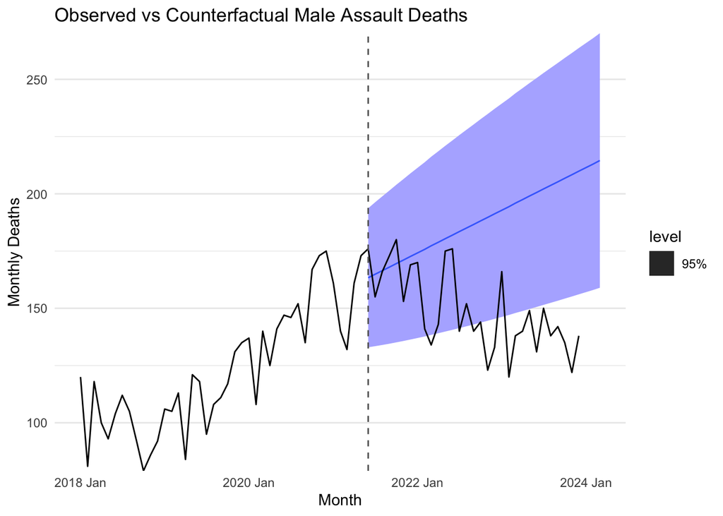

```r
#forecast into post-intervention period  male
fc_m_counterfactual <- m_counterfactual %>%
  forecast(h = 28+6)

 autoplot(fc_m_counterfactual, monthly_m.ts, level = 95) +
  geom_vline(
    xintercept = as.numeric(as_date(make_yearmonth(2021, 6))),
    linetype = "dashed",
    color = "grey40"
  ) +
  labs(
    title = "Observed vs Counterfactual Male Assault Deaths",
    y = "Monthly Deaths",
    x = "Month"
  ) +
  scale_y_continuous(expand = c(0, 0)) +
  theme_minimal() +
  theme(
    panel.grid.major.x = element_blank(),
    panel.grid.minor.x = element_blank()
  )
```

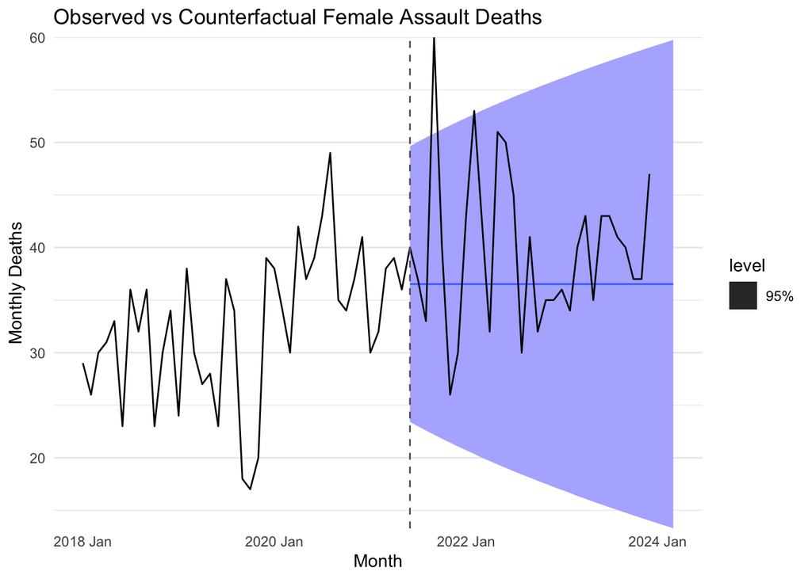

```r
 #forecast into post-intervention period male
fc_f_counterfactual <- f_counterfactual %>%
  forecast(h = 28+6)

 autoplot(fc_f_counterfactual, monthly_f.ts, level = 95) +
  geom_vline(
    xintercept = as.numeric(as_date(make_yearmonth(2021, 6))),
    linetype = "dashed",
    color = "grey40"
  ) +
  labs(
    title = "Observed vs Counterfactual Female Assault Deaths",
    y = "Monthly Deaths",
    x = "Month"
  ) +
  scale_y_continuous(expand = c(0, 0)) +
  theme_minimal() +
  theme(
    panel.grid.major.x = element_blank(),
    panel.grid.minor.x = element_blank()
  )
```

## 3.2 Sensitivity

**Step 1: Fit ARIMA using pre-intervention data only**

Subsetting pre-intervention data:

```r
pre_data_f <- monthly_f.ts %>%
  filter(month_year < as.Date("2021-06-01"))

pre_data_m <- monthly_m.ts %>%
  filter(month_year < as.Date("2021-06-01"))
```

Selecting ARIMA from pre-period data only:

```r
m_pre <- pre_data_m %>%
  model(arima = ARIMA(Deaths, stepwise = FALSE))

f_pre <- pre_data_f %>%
  model(arima = ARIMA(Deaths, stepwise = FALSE))
```

```r
report(m_pre)
```

```
## Series: Deaths
## Model: ARIMA(0,1,1) w/ drift
##
## Coefficients:
##           ma1  constant
##       -0.7330    1.5521
## s.e.   0.1261    0.6969
##
## sigma^2 estimated as 240:  log likelihood=-165.73
## AIC=337.45   AICc=338.12   BIC=342.52
```

```r
report(f_pre)
```

```
## Series: Deaths
## Model: ARIMA(0,1,1)
##
## Coefficients:
##           ma1
##       -0.7451
## s.e.   0.1295
##
## sigma^2 estimated as 44.71:  log likelihood=-132.66
## AIC=269.32   AICc=269.65   BIC=272.7
```

**Step 2: Refit to full data**

```r
m_sensitivity <- monthly_m.ts %>%
  model(
    arima = ARIMA(
      Deaths ~ step + ramp + pdq(0,1,1),
      stepwise = FALSE
    )
  )

f_sensitivity <- monthly_f.ts %>%
  model(
    arima = ARIMA(
      Deaths ~ step + ramp + pdq(0,1,1),
      stepwise = FALSE
    )
  )
```

**Step 3: Comparing estimates**

```r
#male
report(m_arima)
```

```
## Series: Deaths
## Model: LM w/ ARIMA(0,1,1)(0,0,1)[12] errors
##
## Coefficients:
##           ma1   sma1    step     ramp  intercept
##       -0.8094  0.326  5.0309  -2.6469     1.5687
## s.e.   0.0866  0.144  8.4125   0.9048     0.5956
##
## sigma^2 estimated as 210.9:  log likelihood=-289.3
## AIC=590.6   AICc=591.91   BIC=604.18
```

```r
report(m_sensitivity)
```

```
## Series: Deaths
## Model: LM w/ ARIMA(0,1,1)(0,0,1)[12] errors
##
## Coefficients:
##           ma1   sma1    step     ramp  intercept
##       -0.8094  0.326  5.0309  -2.6469     1.5687
## s.e.   0.0866  0.144  8.4125   0.9048     0.5956
##
## sigma^2 estimated as 210.9:  log likelihood=-289.3
## AIC=590.6   AICc=591.91   BIC=604.18
```

```r
#female
report(f_arima)
```

```
## Series: Deaths
## Model: LM w/ ARIMA(0,0,5) errors
##
## Coefficients:
##          ma1     ma2     ma3     ma4     ma5    step     ramp  intercept
##       0.1859  0.0016  0.1026  0.4156  0.3399  9.4181  -0.0682    31.9866
## s.e.  0.1089  0.1029  0.1164  0.1490  0.1287  4.0718   0.2071     1.9153
##
## sigma^2 estimated as 44.31:  log likelihood=-235.08
## AIC=488.16   AICc=491.06   BIC=508.65
```

```r
report(f_sensitivity)
```

```
## Series: Deaths
## Model: LM w/ ARIMA(0,1,1) errors
##
## Coefficients:
##           ma1    step    ramp
##       -0.8719  3.8940  0.0037
## s.e.   0.0753  4.0353  0.2238
##
## sigma^2 estimated as 52.93:  log likelihood=-240.83
## AIC=489.65   AICc=490.26   BIC=498.7
```